# Proration and Analysis of Programmatic Guaranteed Ad Revenue

### Introduction to the Data

```python
#import neccesary libraries
import pandas as pd
import numpy as np
import matplotlib.pyplot as plt
```

```python
#load the pg data and the lkup data into separate dataframes based on the sheet name
pg_df = pd.read_excel('pgdata.xlsx', sheet_name = 'booked')
lkup_df = pd.read_excel('pgdata.xlsx', sheet_name = 'lookup')
```

```python
pg_df.head()
```

|  | start_date | end_date | name | deal_id | budget_microAmount |
| --- | --- | --- | --- | --- | --- |
| 0 | 2022-01-01 | 2022-03-31 | techrepublic_technology_Q1 | 18374 | 70000000000 |
| 1 | 2022-02-01 | 2022-02-28 | housegoods_lifestyle_february | 10423 | 20000000000 |
| 2 | 2022-01-23 | 2022-01-23 | foogle_hpto_january | 29753 | 100000000000 |
| 3 | 2022-01-01 | 2022-06-30 | fiscalbankofamerica_ron_H1 | 10394 | 80000000000 |
| 4 | 2022-04-01 | 2022-04-29 | travelmag_travel_april | 49302 | 20000000000 |

PG deals are a unique form of programmatic in that there is a contracted number of impressions for each deal at a fixed CPM. This allows us to know how much revenue we can expect from each deal before they go live or conclude.

Looking at the column "budget_microAmount" we can clearly see that these huge numbers are likely inaccurate. From previous experience using Google's API we know that "budget_microAmount" is the deal revenue in micro dollars. We will convert this number to standard USD for easier use.

```python
#convert micro dollars to standard USD
pg_df["revenue"] = pg_df.budget_microAmount / 1000000
pg_df.head()
```

|  | start_date | end_date | name | deal_id | budget_microAmount | revenue |
| --- | --- | --- | --- | --- | --- | --- |
| 0 | 2022-01-01 | 2022-03-31 | techrepublic_technology_Q1 | 18374 | 70000000000 | 70000.0 |
| 1 | 2022-02-01 | 2022-02-28 | housegoods_lifestyle_february | 10423 | 20000000000 | 20000.0 |
| 2 | 2022-01-23 | 2022-01-23 | foogle_hpto_january | 29753 | 100000000000 | 100000.0 |
| 3 | 2022-01-01 | 2022-06-30 | fiscalbankofamerica_ron_H1 | 10394 | 80000000000 | 80000.0 |
| 4 | 2022-04-01 | 2022-04-29 | travelmag_travel_april | 49302 | 20000000000 | 20000.0 |

We now have the correct revenue amount for each deal. Looking at the `start_date` and `end_date` columns we can see that many of these deals span multiple months. The data in its current form does not allow us to easily analyze revenue trends over time. We will create a proration process so that we can get a sense of how much PG revenue we can expect over time.

### Proration Script

To prorate this data, we will create a loop which divides each line item's revenue total by the number of days the deal is live. It is important to note that this method assumes even distribution of impressions across a deal's lifetime. Often this is not the case due to user traffic, inventory availability, or adjustments to the `Deliver impressions` setting in GAM. However, based on our domain knowledge of this data we know that nearly all line items are set with even distribution. Traffic fluctuations and inventory will still affect revenue distribution. However, for the purposes of analysis/forecasting this method will provide more than enough precision.

```python
#create an empty list
appended_data = []

for i in np.arange(len(pg_df)):

    #define variables based on current row of data
    start = pg_df['start_date'][i]
    end = pg_df['end_date'][i]
    line_item_name = pg_df['name'][i]
    deal_id = pg_df['deal_id'][i]
    total_rev = pg_df['revenue'][i]

    #use the pandas date_range function to create a DatetimeIndex of values between the start and end date
    date_range = pd.date_range(start, end)

    #divide the total revenue for the deal by the number of days the deal is live
    daily_rev = total_rev / len(date_range)

    #create a temp dataframe based on the date range. add the calculated daily revenue and other columns to the data
    temp_df = date_range.to_frame(index=False, name='day')
    temp_df['revenue'] = daily_rev
    temp_df['line_item'] = line_item_name
    temp_df['deal_id'] = deal_id

    #append the temporary dataframe to the list
    appended_data.append(temp_df)

#concatenate all dataframes into a single dataframe outside of the list
final_df = pd.concat(appended_data)

#add additional date columns
final_df['month'] = final_df['day'].dt.month
final_df['year'] = final_df['day'].dt.year
```

```python
final_df.head()
```

|  | day | revenue | line_item | deal_id | month | year |
| --- | --- | --- | --- | --- | --- | --- |
| 0 | 2022-01-01 | 777.777778 | techrepublic_technology_Q1 | 18374 | 1 | 2022 |
| 1 | 2022-01-02 | 777.777778 | techrepublic_technology_Q1 | 18374 | 1 | 2022 |
| 2 | 2022-01-03 | 777.777778 | techrepublic_technology_Q1 | 18374 | 1 | 2022 |
| 3 | 2022-01-04 | 777.777778 | techrepublic_technology_Q1 | 18374 | 1 | 2022 |
| 4 | 2022-01-05 | 777.777778 | techrepublic_technology_Q1 | 18374 | 1 | 2022 |

We now have our PG data prorated by day. It is important to note that we appended our list of dataframes outside of the for loop. This allows us to only append once, saving memory and thus improving performance. While this is not a concern for such a small dataset, it is best practice and will allow this code to be scalable for larger datasets in the future.

### Merging with Lookup Table for Additional Insights

We have additional information available about each deal in the `line_item` column. However, our business knowledge reminds us that the `line_item` column is not always 100% accurate. Even if we split using a `_` delimiter the resulting data may require additional cleaning. Instead we will take advantage of a mapping file the company keeps for our PG deals. This mapping file is maintained by the financial incentive team so it will allow for some flexibility for things like a sales rep changing half way through the year.

```python
lkup_df.head()
```

|  | deal_id | advertiser | vertical | sales_rep |
| --- | --- | --- | --- | --- |
| 0 | 18374 | tech republic | technology | chris-thomas |
| 1 | 10423 | house goods | cpg | chris-thomas |
| 2 | 29753 | foogle | technology | melissa-morris |
| 3 | 10394 | fiscal bank | finance | emily-stern |
| 4 | 49302 | travel mag | travel | melissa-morris |

This lookup file contains useful information on the advertiser, vertical, and sales rep assigned to each deal. It also includes `deal_id` column which is a unique identifier and allows us to join this data to our prorated PG revenue.

```python
lkup_df = lkup_df.drop_duplicates(subset="deal_id").reset_index(drop=True)
```

```python
#join the prorated PG revenue with the lkup file to get additional data columns
merged_df = final_df.merge(lkup_df, how='left', on='deal_id')
merged_df.head()
```

|  | day | revenue | line_item | deal_id | month | year | advertiser | vertical | sales_rep |
| --- | --- | --- | --- | --- | --- | --- | --- | --- | --- |
| 0 | 2022-01-01 | 777.777778 | techrepublic_technology_Q1 | 18374 | 1 | 2022 | tech republic | technology | chris-thomas |
| 1 | 2022-01-02 | 777.777778 | techrepublic_technology_Q1 | 18374 | 1 | 2022 | tech republic | technology | chris-thomas |
| 2 | 2022-01-03 | 777.777778 | techrepublic_technology_Q1 | 18374 | 1 | 2022 | tech republic | technology | chris-thomas |
| 3 | 2022-01-04 | 777.777778 | techrepublic_technology_Q1 | 18374 | 1 | 2022 | tech republic | technology | chris-thomas |
| 4 | 2022-01-05 | 777.777778 | techrepublic_technology_Q1 | 18374 | 1 | 2022 | tech republic | technology | chris-thomas |

We now have a clean dataset that includes both the prorated daily revenue and important deal information such as the sales rep assigned.

### Analysis

```python
pd.pivot_table(merged_df, values="revenue", index="month", aggfunc="sum", margins=True)
```

| month | revenue |
| --- | --- |
| 1 | 137812.768570 |
| 2 | 54153.468386 |
| 3 | 37812.768570 |
| 4 | 70077.850326 |
| 5 | 52312.047069 |
| 6 | 42831.097080 |
| 7 | 100217.391304 |
| 8 | 20217.391304 |
| 9 | 19565.217391 |
| 10 | 20217.391304 |
| 11 | 19565.217391 |
| 12 | 20217.391304 |
| All | 595000.000000 |

Overall we have $595k in booked PG revenue for 2022. The pivot table above shows the revenue split by month. It is hard to understand what trends exist in this view. We can visualize this data to get a better perspective of our expected PG revenue.

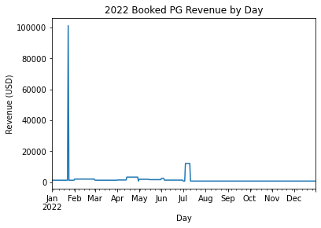

```python
merged_df.groupby("day").sum()['revenue'].plot()
plt.title("2022 Booked PG Revenue by Day")
plt.xlabel("Day")
plt.ylabel("Revenue (USD)")
```

Graphing this data by day shows a few outliers. These outliers are most likely real datapoints where a deal was set as a sponsorship. This is common for deals involving homepage takeovers or section takeovers where an advertiser is guaranteed every impression available for a set time period. In the future we may want to create a process which allows for product to be extracted from the `line_item`. However, for the purpose of this project we will continue by analyzing the data by month to see higher level trends.

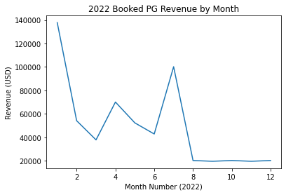

```python
merged_df.groupby("month").sum()['revenue'].plot()
plt.title("2022 Booked PG Revenue by Month")
plt.xlabel("Month Number (2022)")
plt.ylabel("Revenue (USD)")
```

The plot above shows us that January (Month 1) was our best month for PG revenue. There is also a concerning drop in revenue from August (Month 8) onward. Using our knowledge of advertising this drop actually makes sense since this data was pulled sometime mid June. Agencies/advertisers have likely not had time to start their Q3 or Q4 budgets. However, it is still an important trend to point out as it gives us an idea of where we currently stand. Should the later months of the year not see any improvement as we near the end of June, that would be a large concern and our forecasts to Finance should specifically point to this information.

This data can be considered a "Master" dataset of sorts. In addition to trends over time, we can also analyze other aspects of this data. For example, the VP of Sales has requested information on how specific reps are doing in comparison to one another. This can be easily accomplished with this data.

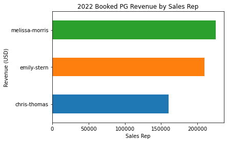

```python
merged_df.groupby("sales_rep").sum()['revenue'].plot.barh(color=['tab:blue','tab:orange','tab:green'])
plt.title("2022 Booked PG Revenue by Sales Rep")
plt.xlabel("Sales Rep")
plt.ylabel("Revenue (USD)")
```

From the above bar chart we can see that Melissa is currently the top Sales Rep in the PG space, with Emily close behind her.

Breaking this data out by month allows for even further analysis.

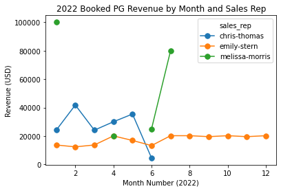

```python
pd.pivot_table(merged_df, index=["month"], columns="sales_rep",
               values="revenue", aggfunc=sum).plot(style='.-', markersize=15)
plt.title("2022 Booked PG Revenue by Month and Sales Rep")
plt.xlabel("Month Number (2022)")
plt.ylabel("Revenue (USD)")
```

The above tells us some very useful information. Despite being the second highest sales rep by revenue, Emily typically has the lowest monthly revenue. Her success is a product of securing ad dollars for 2022 Q3 and Q4 during the first half of the year. Melissa is the top performer but her sales are inconsistent. This may be a result of the accounts assigned to her and the ad products they prefer. That being said it allows us to find an additional area of opportunity for Melissa to continue to succeed. Finally, we know from the original chart that Chris is the lowest performer by revenue. Focusing on 2022 H1 we actually see that he has a higher monthly average compared to Emily. His deals are also more consistent than Melissa. Should the revenue trends in H1 continue throughout the rest of 2022 it is possible for Chris to end up on top of the sales leaderboard.

### Next Steps

The above insights are examples of the type of analysis this data allows for. Moving forward it is would be best to meet with sales leaders and determine what metrics are most useful to track. These views could be placed into an automated dashboard for continued monitoring and analysis.

In addition to analysis/dashboards, this data will be extremely important when providing revenue pacing information to Finance. It is a leading indicator for how future months will close. For example, July is likely to be a strong month for programmatic due already securing a large amount of PG revenue before the month has begun. June is likely to be a relatively average month looking at what is booked. It would require a large amount of in-month booking to become a strong PG month. Past experience has told us that large in-month bookings are typically rare (although not unheard of).